# week_11_binary_classification

```python
fit_03.params[0] + fit_03.params[2]
```

```
-0.35020242943311486
```

Fit a model with **all** linear additive features for the continuous **and** the categorical inputs.

```python
fit_04 = smf.logit( formula = 'y ~ x1 + x2 + x3 + x4 + x5', data = df).fit()
```

```
Optimization terminated successfully.
         Current function value: 0.588229
         Iterations 5
```

```python
print( fit_04.summary() )
```

```
                           Logit Regression Results
==============================================================================
Dep. Variable:                      y   No. Observations:                  300
Model:                          Logit   Df Residuals:                      293
Method:                           MLE   Df Model:                            6
Date:                Thu, 11 Nov 2021   Pseudo R-squ.:                 0.08238
Time:                        20:26:16   Log-Likelihood:                -176.47
converged:                       True   LL-Null:                       -192.31
Covariance Type:            nonrobust   LLR p-value:                 1.876e-05
==============================================================================
                 coef    std err          z      P>|z|      [0.025      0.975]
------------------------------------------------------------------------------
Intercept     -0.6745      0.254     -2.653      0.008      -1.173      -0.176
x5[T.b]       -0.2898      0.314     -0.922      0.357      -0.906       0.326
x5[T.c]        0.3100      0.354      0.876      0.381      -0.383       1.003
x1             0.3104      0.130      2.383      0.017       0.055       0.566
x2            -0.5796      0.137     -4.220      0.000      -0.849      -0.310
x3             0.1139      0.130      0.877      0.380      -0.140       0.368
x4            -0.0488      0.130     -0.374      0.709      -0.304       0.207
==============================================================================
```

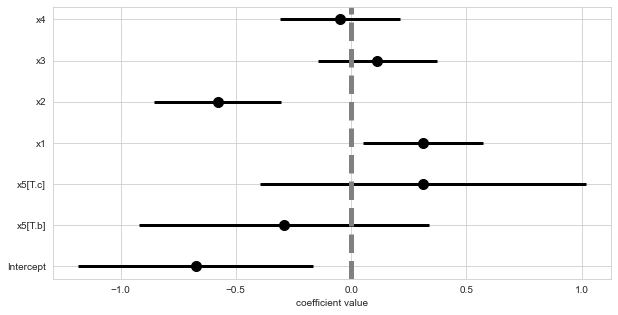

```python
my_coefplot( fit_04 )
```

Next, interact the categorical with all continuous inputs.

```python
fit_05 = smf.logit(formula = 'y ~ x5 * (x1 + x2 + x3 + x4)', data = df).fit()
```

```
Optimization terminated successfully.
         Current function value: 0.569593
         Iterations 6
```

```python
print( fit_05.summary() )
```

```
                           Logit Regression Results
==============================================================================
Dep. Variable:                      y   No. Observations:                  300
Model:                          Logit   Df Residuals:                      285
Method:                           MLE   Df Model:                           14
Date:                Thu, 11 Nov 2021   Pseudo R-squ.:                  0.1114
Time:                        20:29:56   Log-Likelihood:                -170.88
converged:                       True   LL-Null:                       -192.31
Covariance Type:            nonrobust   LLR p-value:                 9.001e-05
==============================================================================
                 coef    std err          z      P>|z|      [0.025      0.975]
------------------------------------------------------------------------------
Intercept     -0.6359      0.257     -2.470      0.014      -1.141      -0.131
x5[T.b]       -0.3382      0.323     -1.048      0.295      -0.971       0.294
x5[T.c]        0.2464      0.374      0.659      0.510      -0.486       0.979
x1             0.0816      0.222      0.368      0.713      -0.354       0.517
x5[T.b]:x1     0.2089      0.305      0.685      0.493      -0.389       0.806
x5[T.c]:x1     0.6606      0.381      1.732      0.083      -0.087       1.408
x2            -0.6515      0.303     -2.149      0.032      -1.246      -0.057
x5[T.b]:x2     0.2146      0.360      0.596      0.551      -0.492       0.921
x5[T.c]:x2    -0.2036      0.423     -0.482      0.630      -1.032       0.625
x3            -0.1925      0.221     -0.870      0.384      -0.626       0.241
x5[T.b]:x3     0.7090      0.309      2.294      0.022       0.103       1.315
x5[T.c]:x3     0.0380      0.368      0.103      0.918      -0.684       0.760
x4            -0.1100      0.245     -0.449      0.654      -0.591       0.371
x5[T.b]:x4    -0.0086      0.310     -0.028      0.978      -0.616       0.599
x5[T.c]:x4     0.0954      0.382      0.250      0.803      -0.653       0.844
==============================================================================
```

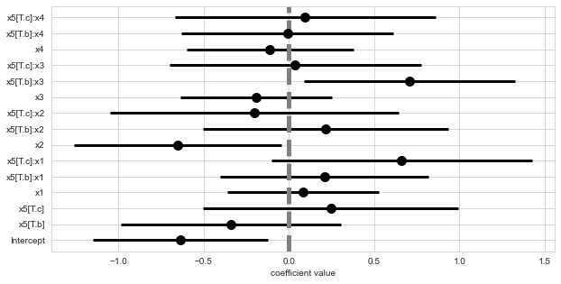

```python
my_coefplot( fit_05 )
```

Create all pairwise interactions including the categorical.

```python
fit_06 = smf.logit(formula='y ~ (x1 + x2 + x3 + x4 + x5) ** 2', data = df).fit()
```

```
Optimization terminated successfully.
         Current function value: 0.560799
         Iterations 6
```

```python
print( fit_06.summary() )
```

```
                           Logit Regression Results
==============================================================================
Dep. Variable:                      y   No. Observations:                  300
Model:                          Logit   Df Residuals:                      279
Method:                           MLE   Df Model:                           20
Date:                Thu, 11 Nov 2021   Pseudo R-squ.:                  0.1252
Time:                        20:32:33   Log-Likelihood:                -168.24
converged:                       True   LL-Null:                       -192.31
Covariance Type:            nonrobust   LLR p-value:                 0.0004063
==============================================================================
                 coef    std err          z      P>|z|      [0.025      0.975]
------------------------------------------------------------------------------
Intercept     -0.5601      0.261     -2.146      0.032      -1.072      -0.049
x5[T.b]       -0.4562      0.333     -1.371      0.170      -1.108       0.196
x5[T.c]        0.2051      0.378      0.542      0.588      -0.536       0.946
x1             0.0296      0.231      0.128      0.898      -0.423       0.482
x1:x5[T.b]     0.3027      0.314      0.964      0.335      -0.313       0.918
x1:x5[T.c]     0.7033      0.385      1.828      0.068      -0.051       1.457
x2            -0.6876      0.314     -2.187      0.029      -1.304      -0.071
x2:x5[T.b]     0.2158      0.373      0.578      0.563      -0.515       0.947
x2:x5[T.c]    -0.1467      0.431     -0.340      0.734      -0.991       0.698
x3            -0.2010      0.241     -0.836      0.403      -0.672       0.270
x3:x5[T.b]     0.7845      0.332      2.359      0.018       0.133       1.436
x3:x5[T.c]     0.0440      0.382      0.115      0.908      -0.705       0.793
x4            -0.0523      0.258     -0.203      0.839      -0.557       0.453
x4:x5[T.b]    -0.0678      0.322     -0.210      0.833      -0.699       0.564
x4:x5[T.c]     0.0985      0.392      0.251      0.802      -0.670       0.867
x1:x2          0.0351      0.162      0.217      0.828      -0.282       0.352
x1:x3          0.0208      0.139      0.149      0.881      -0.252       0.293
x1:x4         -0.0891      0.141     -0.632      0.527      -0.365       0.187
x2:x3          0.2099      0.154      1.364      0.173      -0.092       0.512
x2:x4         -0.0559      0.145     -0.385      0.700      -0.340       0.229
x3:x4          0.2466      0.151      1.628      0.103      -0.050       0.544
==============================================================================
```

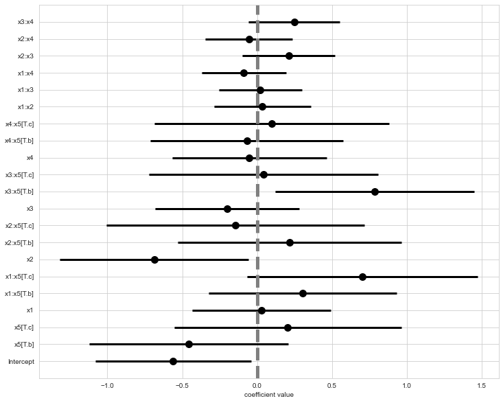

```python
my_coefplot( fit_06, figsize_use=(12, 10))
```

We can create all **triplet** or **three-way** interactions.

```python
fit_07 = smf.logit(formula = 'y ~ (x1 + x2 + x3 + x4 + x5) ** 3', data = df).fit()
```

```
Optimization terminated successfully.
         Current function value: 0.526975
         Iterations 7
```

```python
print( fit_07.summary() )
```

```
                           Logit Regression Results
==============================================================================
Dep. Variable:                      y   No. Observations:                  300
Model:                          Logit   Df Residuals:                      263
Method:                           MLE   Df Model:                           36
Date:                Thu, 11 Nov 2021   Pseudo R-squ.:                  0.1779
Time:                        20:34:23   Log-Likelihood:                -158.09
converged:                       True   LL-Null:                       -192.31
Covariance Type:            nonrobust   LLR p-value:                 0.0008882
=================================================================================
                    coef    std err          z      P>|z|      [0.025      0.975]
---------------------------------------------------------------------------------
Intercept        -0.5142      0.279     -1.840      0.066      -1.062       0.034
x5[T.b]          -0.6577      0.367     -1.793      0.073      -1.377       0.061
x5[T.c]           0.2024      0.415      0.488      0.626      -0.611       1.016
x1                0.0573      0.264      0.217      0.829      -0.461       0.575
x1:x5[T.b]        0.3975      0.368      1.080      0.280      -0.324       1.119
x1:x5[T.c]        0.8344      0.446      1.871      0.061      -0.040       1.708
x2               -0.8079      0.354     -2.283      0.022      -1.502      -0.114
x2:x5[T.b]        0.1968      0.421      0.467      0.640      -0.629       1.022
x2:x5[T.c]       -0.0908      0.497     -0.183      0.855      -1.065       0.883
x3               -0.1705      0.280     -0.609      0.542      -0.719       0.378
x3:x5[T.b]        0.9661      0.381      2.534      0.011       0.219       1.713
x3:x5[T.c]       -0.1365      0.443     -0.308      0.758      -1.004       0.731
x4                0.0408      0.292      0.140      0.889      -0.531       0.612
x4:x5[T.b]       -0.0697      0.359     -0.194      0.846      -0.772       0.633
x4:x5[T.c]       -0.0219      0.468     -0.047      0.963      -0.939       0.895
x1:x2             0.0075      0.384      0.020      0.984      -0.745       0.760
x1:x2:x5[T.b]     0.3063      0.447      0.685      0.493      -0.570       1.183
x1:x2:x5[T.c]    -0.7400      0.611     -1.211      0.226      -1.938       0.458
x1:x3             0.0271      0.236      0.115      0.908      -0.435       0.489
x1:x3:x5[T.b]    -0.3598      0.377     -0.954      0.340      -1.099       0.379
x1:x3:x5[T.c]    -0.0578      0.461     -0.125      0.900      -0.962       0.846
x1:x4             0.3740      0.304      1.229      0.219      -0.223       0.971
x1:x4:x5[T.b]    -0.6916      0.375     -1.844      0.065      -1.427       0.044
x1:x4:x5[T.c]    -0.3696      0.490     -0.754      0.451      -1.330       0.591
x2:x3             0.1713      0.384      0.446      0.655      -0.581       0.924
x2:x3:x5[T.b]     0.3129      0.473      0.662      0.508      -0.614       1.240
x2:x3:x5[T.c]    -0.2879      0.543     -0.530      0.596      -1.352       0.776
x2:x4             0.0770      0.404      0.191      0.849      -0.715       0.869
x2:x4:x5[T.b]    -0.1451      0.461     -0.314      0.753      -1.050       0.759
x2:x4:x5[T.c]    -0.2274      0.533     -0.427      0.669      -1.271       0.816
x3:x4             0.5003      0.335      1.492      0.136      -0.157       1.158
x3:x4:x5[T.b]    -0.7065      0.446     -1.586      0.113      -1.580       0.167
x3:x4:x5[T.c]    -0.1240      0.481     -0.258      0.797      -1.068       0.820
x1:x2:x3         -0.3226      0.198     -1.630      0.103      -0.710       0.065
x1:x2:x4          0.0038      0.208      0.018      0.985      -0.403       0.411
x1:x3:x4          0.1859      0.198      0.939      0.348      -0.202       0.574
x2:x3:x4         -0.3251      0.209     -1.559      0.119      -0.734       0.084
=================================================================================
```

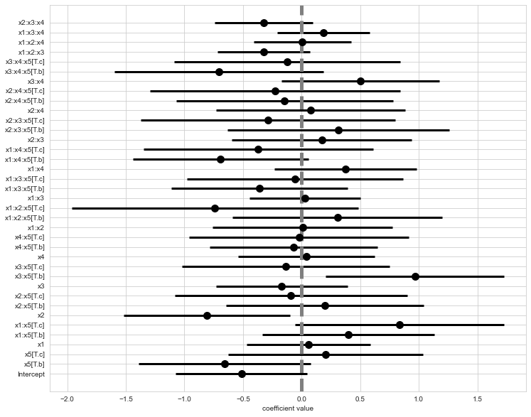

```python
my_coefplot(fit_07, figsize_use=(12, 10))
```

All 5 way interactions.

```python
fit_08 = smf.logit(formula = 'y ~ (x1 + x2 + x3 + x4 + x5) ** 5', data = df).fit()
```

```
Optimization terminated successfully.
         Current function value: 0.497195
         Iterations 7
```

```python
len( fit_08.params )
```

```
48
```

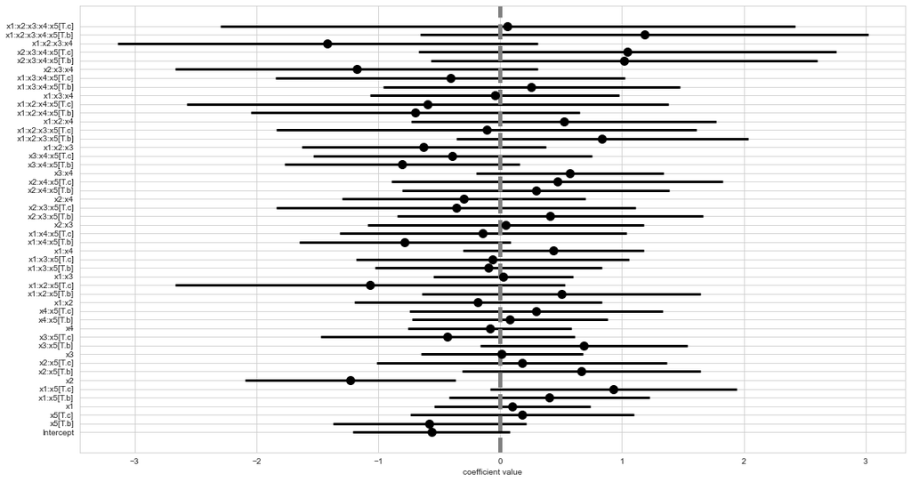

```python
my_coefplot( fit_08, figsize_use=(18, 10))
```

Let's include quadratic features for each continuous input and interact the categorical with the linear continuous features.

```python
fit_09 = smf.logit(formula = 'y ~ np.power(x1, 2) + np.power(x2, 2) + np.power(x3, 2) + np.power(x4, 2) + x5 * (x1 + x2 + x3 + x4)', data = df).fit()
```

```
Optimization terminated successfully.
         Current function value: 0.489643
         Iterations 7
```

```python
print( fit_09.summary() )
```

```
                           Logit Regression Results
==============================================================================
Dep. Variable:                      y   No. Observations:                  300
Model:                          Logit   Df Residuals:                      281
Method:                           MLE   Df Model:                           18
Date:                Thu, 11 Nov 2021   Pseudo R-squ.:                  0.2362
Time:                        20:39:35   Log-Likelihood:                -146.89
converged:                       True   LL-Null:                       -192.31
Covariance Type:            nonrobust   LLR p-value:                 1.022e-11
===================================================================================
                      coef    std err          z      P>|z|      [0.025      0.975]
-----------------------------------------------------------------------------------
Intercept           0.4761      0.378      1.259      0.208      -0.265       1.217
x5[T.b]            -0.5031      0.373     -1.349      0.177      -1.234       0.228
x5[T.c]             0.1662      0.435      0.382      0.702      -0.686       1.018
np.power(x1, 2)    -0.7467      0.177     -4.217      0.000      -1.094      -0.400
np.power(x2, 2)    -0.6357      0.166     -3.835      0.000      -0.961      -0.311
np.power(x3, 2)    -0.1804      0.112     -1.604      0.109      -0.401       0.040
np.power(x4, 2)     0.1556      0.108      1.445      0.148      -0.055       0.367
x1                  0.4623      0.323      1.432      0.152      -0.170       1.095
x5[T.b]:x1         -0.0801      0.412     -0.195      0.846      -0.887       0.727
x5[T.c]:x1          0.4231      0.471      0.899      0.369      -0.499       1.345
x2                 -1.3267      0.426     -3.112      0.002      -2.162      -0.491
x5[T.b]:x2          0.5055      0.467      1.083      0.279      -0.409       1.420
x5[T.c]:x2          0.1922      0.525      0.366      0.714      -0.837       1.221
x3                 -0.0875      0.271     -0.323      0.747      -0.618       0.443
x5[T.b]:x3          0.6513      0.356      1.829      0.067      -0.047       1.349
x5[T.c]:x3         -0.0662      0.405     -0.164      0.870      -0.859       0.727
x4                 -0.1564      0.288     -0.543      0.587      -0.721       0.408
x5[T.b]:x4          0.0758      0.355      0.214      0.831      -0.620       0.771
x5[T.c]:x4          0.2838      0.447      0.634      0.526      -0.593       1.161
===================================================================================
```

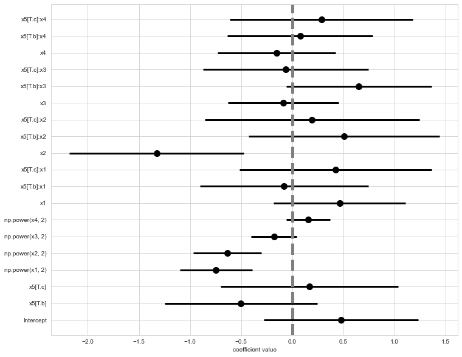

```python
my_coefplot( fit_09, figsize_use=(12,10))
```

```python
fit_10 = smf.logit(formula = 'y ~ x5 * (np.power(x1, 2) + np.power(x2, 2) + np.power(x3, 2) + np.power(x4, 2) + x1 + x2 + x3 + x4)', data = df).fit()
```

```
Optimization terminated successfully.
         Current function value: 0.481047
         Iterations 8
```

```python
print( fit_10.summary() )
```

```
                           Logit Regression Results
==============================================================================
Dep. Variable:                      y   No. Observations:                  300
Model:                          Logit   Df Residuals:                      273
Method:                           MLE   Df Model:                           26
Date:                Thu, 11 Nov 2021   Pseudo R-squ.:                  0.2496
Time:                        20:45:29   Log-Likelihood:                -144.31
converged:                       True   LL-Null:                       -192.31
Covariance Type:            nonrobust   LLR p-value:                 5.898e-10
===========================================================================================
                              coef    std err          z      P>|z|      [0.025      0.975]
-------------------------------------------------------------------------------------------
Intercept                   0.7068      0.541      1.305      0.192      -0.354       1.768
x5[T.b]                    -1.1574      0.658     -1.759      0.079      -2.447       0.132
x5[T.c]                     0.3190      0.746      0.428      0.669      -1.143       1.781
np.power(x1, 2)            -0.9465      0.347     -2.728      0.006      -1.627      -0.266
x5[T.b]:np.power(x1, 2)     0.4259      0.426      0.999      0.318      -0.410       1.262
x5[T.c]:np.power(x1, 2)     0.0182      0.516      0.035      0.972      -0.994       1.030
np.power(x2, 2)            -0.6125      0.302     -2.025      0.043      -1.205      -0.020
x5[T.b]:np.power(x2, 2)     0.0162      0.390      0.041      0.967      -0.749       0.781
x5[T.c]:np.power(x2, 2)    -0.1538      0.455     -0.338      0.736      -1.046       0.739
np.power(x3, 2)            -0.2729      0.187     -1.461      0.144      -0.639       0.093
x5[T.b]:np.power(x3, 2)     0.3117      0.284      1.097      0.272      -0.245       0.869
x5[T.c]:np.power(x3, 2)     0.1569      0.318      0.494      0.621      -0.466       0.780
np.power(x4, 2)             0.1816      0.208      0.874      0.382      -0.226       0.589
x5[T.b]:np.power(x4, 2)     0.0655      0.255      0.257      0.797      -0.434       0.565
x5[T.c]:np.power(x4, 2)    -0.3479      0.311     -1.118      0.263      -0.958       0.262
x1                          0.5406      0.376      1.437      0.151      -0.197       1.278
x5[T.b]:x1                 -0.2126      0.452     -0.470      0.638      -1.099       0.674
x5[T.c]:x1                  0.4974      0.590      0.843      0.399      -0.659       1.654
x2                         -1.3295      0.500     -2.661      0.008      -2.309      -0.350
x5[T.b]:x2                  0.5373      0.574      0.937      0.349      -0.587       1.662
x5[T.c]:x2                  0.1002      0.684      0.147      0.883      -1.240       1.440
x3                         -0.0502      0.302     -0.166      0.868      -0.642       0.541
x5[T.b]:x3                  0.6021      0.378      1.595      0.111      -0.138       1.342
x5[T.c]:x3                 -0.2036      0.441     -0.462      0.644      -1.068       0.660
x4                         -0.1887      0.318     -0.594      0.552      -0.811       0.434
x5[T.b]:x4                  0.1053      0.374      0.282      0.778      -0.627       0.838
x5[T.c]:x4                  0.3844      0.465      0.827      0.408      -0.526       1.295
===========================================================================================
```

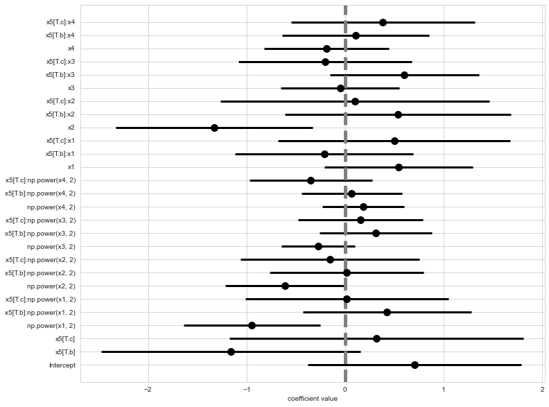

```python
my_coefplot( fit_10, figsize_use=(12, 10))
```

## Binary classification performance metrics

```python
mod_list = [fit_01, fit_02, fit_03, fit_04, fit_05, fit_06, fit_07, fit_08, fit_09, fit_10]
```

```python
print( mod_list[2].summary() )
```

```
                           Logit Regression Results
==============================================================================
Dep. Variable:                      y   No. Observations:                  300
Model:                          Logit   Df Residuals:                      297
Method:                           MLE   Df Model:                            2
Date:                Thu, 11 Nov 2021   Pseudo R-squ.:                 0.01057
Time:                        20:47:49   Log-Likelihood:                -190.28
converged:                       True   LL-Null:                       -192.31
Covariance Type:            nonrobust   LLR p-value:                    0.1309
==============================================================================
                 coef    std err          z      P>|z|      [0.025      0.975]
------------------------------------------------------------------------------
Intercept     -0.5179      0.239     -2.170      0.030      -0.986      -0.050
x5[T.b]       -0.3937      0.299     -1.315      0.188      -0.980       0.193
x5[T.c]        0.1677      0.335      0.501      0.616      -0.488       0.824
==============================================================================
```

Predict the event probability on the training set for each model.

```python
df_copy_b = df.copy()
```

```python
'pred_probability_'+str(1)
```

```
'pred_probability_1'
```

```python
'pred_probability_'+str(10)
```

```
'pred_probability_10'
```

```python
'pred_probability_'+str(1).zfill(2)
```

```
'pred_probability_01'
```

```python
for i, mod in enumerate(mod_list):
    df_copy_b['pred_probability_'+str(i+1).zfill(2)] = mod.predict(df)
```

```python
df_copy_b
```

|  | x1 | x2 | x3 | x4 | x5 | y | pred_probability_01 | pred_probability_02 | pred_probability_03 | pred_probability_04 | pred_probability_05 | pred_probability_06 | pred_probability_07 | pred_probability_08 | pred_probability_09 | pred_probability_10 |
| --- | --- | --- | --- | --- | --- | --- | --- | --- | --- | --- | --- | --- | --- | --- | --- | --- |
| 0 | 1.077412 | -0.991094 | 0.208610 | -1.019744 | c | 1 | 0.561362 | 0.544294 | 0.413333 | 0.649739 | 0.775635 | 0.749228 | 0.879060 | 0.925002 | 0.772279 | 0.750589 |
| 1 | -0.637747 | -0.307506 | -1.794250 | 1.189993 | b | 0 | 0.262697 | 0.218863 | 0.286667 | 0.223334 | 0.109786 | 0.071407 | 0.127017 | 0.201577 | 0.135894 | 0.214353 |
| 2 | 1.345143 | -1.075281 | 1.685044 | 0.167879 | b | 0 | 0.623647 | 0.579207 | 0.286667 | 0.564661 | 0.676346 | 0.640372 | 0.545974 | 0.371830 | 0.428646 | 0.560775 |
| 3 | 1.659924 | 0.735156 | -0.210541 | -2.534105 | b | 1 | 0.365854 | 0.438791 | 0.286667 | 0.315269 | 0.349479 | 0.495887 | 0.715955 | 0.779253 | 0.210641 | 0.363179 |
| 4 | 1.182378 | 1.599140 | -0.301995 | 1.206648 | b | 0 | 0.200295 | 0.133946 | 0.286667 | 0.165568 | 0.164046 | 0.112427 | 0.165825 | 0.116969 | 0.026200 | 0.029703 |
| ... | ... | ... | ... | ... | ... | ... | ... | ... | ... | ... | ... | ... | ... | ... | ... | ... |
| 295 | 1.239739 | 1.572756 | 0.610548 | 1.402896 | c | 0 | 0.223071 | 0.220997 | 0.413333 | 0.291098 | 0.283076 | 0.361012 | 0.049258 | 0.001601 | 0.080120 | 0.039403 |
| 296 | -0.528292 | 3.120873 | 0.357688 | -0.599724 | c | 0 | 0.067360 | 0.096750 | 0.413333 | 0.093870 | 0.029396 | 0.037913 | 0.120186 | 0.042600 | 0.000052 | 0.000012 |
| 297 | 0.256334 | 1.293508 | 0.023925 | -0.996928 | b | 0 | 0.205614 | 0.220957 | 0.286667 | 0.170353 | 0.208458 | 0.214073 | 0.182104 | 0.191399 | 0.135205 | 0.110929 |
| 298 | -0.628451 | 0.373513 | 0.038140 | 2.197234 | b | 1 | 0.223857 | 0.238097 | 0.286667 | 0.185632 | 0.173541 | 0.174945 | 0.192861 | 0.233445 | 0.410435 | 0.447552 |
| 299 | 1.250264 | 1.105026 | 0.593161 | -0.584460 | b | 1 | 0.292519 | 0.307922 | 0.286667 | 0.245886 | 0.327831 | 0.380205 | 0.459666 | 0.667800 | 0.116186 | 0.120932 |

300 rows × 16 columns

Classify by comparing the predicted probability to a threshold. Use the default threshold of 0.5.

```python
for i in range(len(mod_list)):
    df_copy_b['pred_class_'+str(i+1).zfill(2)] = np.where( df_copy_b['pred_probability_'+str(i+1).zfill(2)] > 0.5, 1, 0)
```

```python
df_copy_b
```

|  | x1 | x2 | x3 | x4 | x5 | y | pred_probability_01 | pred_probability_02 | pred_probability_03 | pred_probability_04 | ... | pred_class_01 | pred_class_02 | pred_class_03 | pred_class_04 | pred_class_05 | pred_class_06 | pred_class_07 | pred_class_08 | pred_class_09 | pred_class_10 |
| --- | --- | --- | --- | --- | --- | --- | --- | --- | --- | --- | --- | --- | --- | --- | --- | --- | --- | --- | --- | --- | --- |
| 0 | 1.077412 | -0.991094 | 0.208610 | -1.019744 | c | 1 | 0.561362 | 0.544294 | 0.413333 | 0.649739 | ... | 1 | 1 | 0 | 1 | 1 | 1 | 1 | 1 | 1 | 1 |
| 1 | -0.637747 | -0.307506 | -1.794250 | 1.189993 | b | 0 | 0.262697 | 0.218863 | 0.286667 | 0.223334 | ... | 0 | 0 | 0 | 0 | 0 | 0 | 0 | 0 | 0 | 0 |
| 2 | 1.345143 | -1.075281 | 1.685044 | 0.167879 | b | 0 | 0.623647 | 0.579207 | 0.286667 | 0.564661 | ... | 1 | 1 | 0 | 1 | 1 | 1 | 1 | 0 | 0 | 1 |
| 3 | 1.659924 | 0.735156 | -0.210541 | -2.534105 | b | 1 | 0.365854 | 0.438791 | 0.286667 | 0.315269 | ... | 0 | 0 | 0 | 0 | 0 | 0 | 1 | 1 | 0 | 0 |
| 4 | 1.182378 | 1.599140 | -0.301995 | 1.206648 | b | 0 | 0.200295 | 0.133946 | 0.286667 | 0.165568 | ... | 0 | 0 | 0 | 0 | 0 | 0 | 0 | 0 | 0 | 0 |
| ... | ... | ... | ... | ... | ... | ... | ... | ... | ... | ... | ... | ... | ... | ... | ... | ... | ... | ... | ... | ... | ... |
| 295 | 1.239739 | 1.572756 | 0.610548 | 1.402896 | c | 0 | 0.223071 | 0.220997 | 0.413333 | 0.291098 | ... | 0 | 0 | 0 | 0 | 0 | 0 | 0 | 0 | 0 | 0 |
| 296 | -0.528292 | 3.120873 | 0.357688 | -0.599724 | c | 0 | 0.067360 | 0.096750 | 0.413333 | 0.093870 | ... | 0 | 0 | 0 | 0 | 0 | 0 | 0 | 0 | 0 | 0 |
| 297 | 0.256334 | 1.293508 | 0.023925 | -0.996928 | b | 0 | 0.205614 | 0.220957 | 0.286667 | 0.170353 | ... | 0 | 0 | 0 | 0 | 0 | 0 | 0 | 0 | 0 | 0 |
| 298 | -0.628451 | 0.373513 | 0.038140 | 2.197234 | b | 1 | 0.223857 | 0.238097 | 0.286667 | 0.185632 | ... | 0 | 0 | 0 | 0 | 0 | 0 | 0 | 0 | 0 | 0 |
| 299 | 1.250264 | 1.105026 | 0.593161 | -0.584460 | b | 1 | 0.292519 | 0.307922 | 0.286667 | 0.245886 | ... | 0 | 0 | 0 | 0 | 0 | 0 | 0 | 1 | 0 | 0 |

300 rows × 26 columns

Calculate the accuracy on the training set.

```python
model_accuracy = []

for i in range(len(mod_list)):
    model_accuracy.append( df_copy_b.loc[ df_copy_b.y == df_copy_b['pred_class_'+str(i+1).zfill(2)] ].shape[0] / df_copy_b.shape[0])
```

```python
model_accuracy
```

```
[0.6266666666666667,
 0.6533333333333333,
 0.66,
 0.66,
 0.6933333333333334,
 0.6966666666666667,
 0.7266666666666667,
 0.7433333333333333,
 0.7566666666666667,
 0.7666666666666667]
```

### Confusion matrix

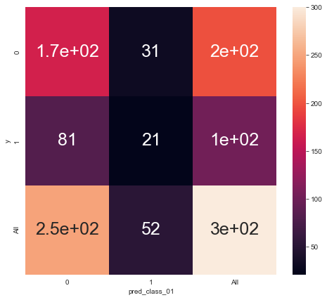

```python
fig, ax = plt.subplots(figsize=(8,7))

sns.heatmap(pd.crosstab(df_copy_b.y, df_copy_b.pred_class_01, margins=True),
            annot=True, annot_kws={'size': 25},
            ax=ax)

plt.show()
```

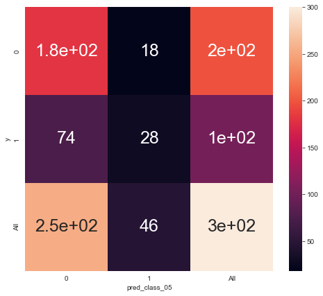

```python
fig, ax = plt.subplots(figsize=(8,7))

sns.heatmap(pd.crosstab(df_copy_b.y, df_copy_b.pred_class_05, margins=True),
            annot=True, annot_kws={'size': 25},
            ax=ax)

plt.show()
```

Vary the threshold.

```python
df_copy_c = df_copy_b.copy()
```

```python
for i in range(len(mod_list)):
    df_copy_c['pred_class_'+str(i+1).zfill(2)] = np.where( df_copy_c['pred_probability_'+str(i+1).zfill(2)] > 0.25, 1, 0)
```

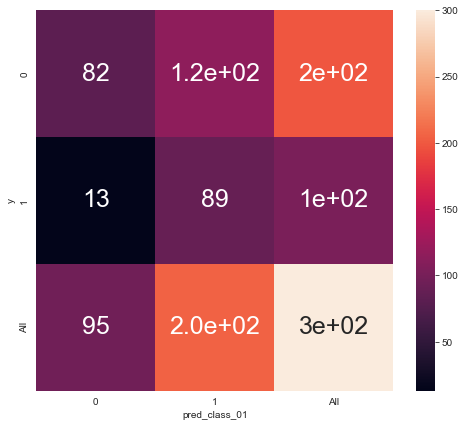

```python
fig, ax = plt.subplots(figsize=(8,7))

sns.heatmap(pd.crosstab(df_copy_c.y, df_copy_c.pred_class_01, margins=True),
            annot=True, annot_kws={'size': 25},
            ax=ax)

plt.show()
```

### ROC curve

```python
from sklearn.metrics import roc_curve
```

```python
def roc_values(mod_id, df_object):
    fpr, tpr, threshold = roc_curve(df_object.y.to_numpy(), df_object['pred_probability_'+str(mod_id+1).zfill(2)].to_numpy())
    res = pd.DataFrame({'fpr': fpr, 'tpr': tpr, 'threshold': threshold})
    res['model_name'] = 'fit_'+str(mod_id+1).zfill(2)

    return res
```

```python
all_roc_curves = []

for i in range(len(mod_list)):
    all_roc_curves.append( roc_values(i, df_copy_b) )
```

```python
all_roc_df = pd.concat(all_roc_curves).reset_index()
```

```python
all_roc_df
```

|  | index | fpr | tpr | threshold | model_name |
| --- | --- | --- | --- | --- | --- |
| 0 | 0 | 0.000000 | 0.000000 | 1.778843 | fit_01 |
| 1 | 1 | 0.005051 | 0.000000 | 0.778843 | fit_01 |
| 2 | 2 | 0.030303 | 0.000000 | 0.623647 | fit_01 |
| 3 | 3 | 0.030303 | 0.009804 | 0.623481 | fit_01 |
| 4 | 4 | 0.035354 | 0.009804 | 0.622756 | fit_01 |
| ... | ... | ... | ... | ... | ... |
| 993 | 99 | 0.626263 | 0.980392 | 0.127307 | fit_10 |
| 994 | 100 | 0.626263 | 0.990196 | 0.120932 | fit_10 |
| 995 | 101 | 0.904040 | 0.990196 | 0.016534 | fit_10 |
| 996 | 102 | 0.904040 | 1.000000 | 0.016297 | fit_10 |
| 997 | 103 | 1.000000 | 1.000000 | 0.000012 | fit_10 |

998 rows × 5 columns

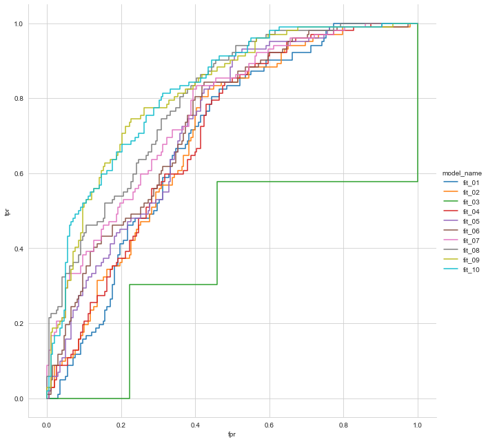

```python
sns.relplot(data = all_roc_df, x='fpr', y='tpr', hue='model_name',
            estimator=None, units='model_name',
            kind='line',
            drawstyle='steps-post',
            height=9)

plt.show()
```